# RSSC Toolkit (`RSSCtk`): Developing analytic weights

### Step 2: Adjusting for Nonresponse

This step adjusts the sampling weights to account for nonresponse using a model based approach. Having successfully run dmdc_wts_elig we have created **ESTATRSP** and **COMPERSP**, target variables that can be modeled to produce eligiblity and completition probabilities for every case included in those respective processes. Predicted probabilities for both variables are produced by modeling the target variables against relevant variables related to response on the survey. Typically these are variables that are used in the stratification process, as well as helpful ancillary data for the sampled members. The initial models are produced using decision trees. Decision trees work well with this type of data as they are flexible, can handle different data types, and can discover complex interactions between the features. Decision tree modeling is currently done using the `party` (Laboratory for Recursive Partioning) package. The framework in `RSSCtk` is designed to be flexible but currently only supports conditional inference trees (`CTREE`). The probabilities for these models can be smoothed by a logistic model or left as is; in R this accomplished using `GLM`. Smoothing will naturally move the probabilities away from the extremes (0 or 1); this can be attractive option to avoid large adjustments that can be possible in edge cases on large scale surveys. The final predicted probabilities (either smoothed or not) are then used to adjust the sampling weight. The formulas for adjustment are discussed in greater detail in the methodology section.

In the example below, the **ESTATRSP** and **COMPERSP** models are target (dependent) variables in a decision tree algorithm. The independent variables are composed of variables used in stratification (Paygrade, Service, Race, Region) as well as additional variables that are relevant to eligiblity and completition including (family status, gender, education, DoD occupation group and age).

The example shows that the decision tree probabilities will be smoothed, `smooth=T`. The decision tree will be constrainted to have a minimum number of 20 sampled members (`min bucket = 20`), will grow to a maximum of six levels (`maxdepth=6`), and make splits based on a test-statistic at the 0.95 level confidence (`mincriterion=0.95,testtype="Teststatistic"`). The output will shown in three stages: predicited probability plots, text tables illustrating each adjustment stage and weighting diagnostics).

##### RSSCtk Function and output:

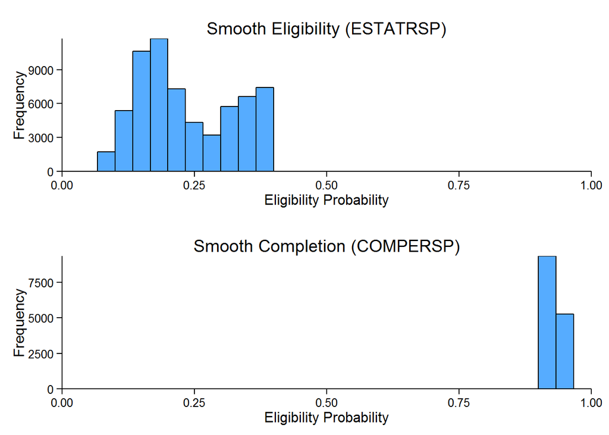

```r
model_variables<-c("PAYGRADE","CSERVICE","CRACECAT","CREGION1","FAMSTAT","CSEX","CEDUC","OCCGROUP")
#hotcode_factors(data=SF1401,vars=model_variables)
model_variables<-c(model_variables,"AGE")


dmdc_wts_models(data=SF1401,
                model_vars=model_variables,
                smooth=T,
                controls=c(minbucket=20,mincriterion=0.95,maxdepth=6,testtype="Teststatistic"),
                verbose=F,
                plots=T,
                diagnostics=F)
```

The above graphs show smoothed model predicted probabilities for **ESTATRSP** and **COMPERSP**. The probabilities will be turned into adjustments that will be distributed to **SAMP_WGT** depending on the specific case of each member. The output below illustrates the text output that accompany the graphs.

##### Verbose Output:

```
##
##
## Eligibility Table
## =================================================================
##                   Min.  1st Qu. Median Mean  3rd Qu.  Max.   SD
## -----------------------------------------------------------------
## Elig. Probability 0.11   0.16    0.20  0.24   0.32    0.40  0.10
## Elig. Adjustment  2.51   2.73    3.67  4.16   4.95    9.30  1.99
## Elig. Weight      14.88  40.44  70.80  91.25 111.10  417.80 52.76
## -----------------------------------------------------------------
##
## Completion Table
## =================================================================
##                   Min.  1st Qu. Median Mean  3rd Qu.  Max.   SD
## -----------------------------------------------------------------
## Comp. Probability 0.89   0.90    0.93  0.92   0.95    0.96  0.03
## Comp. Adjustment  1.04   1.05    1.07  1.08   1.11    1.13  0.03
## Comp. Weight      15.54  42.24  74.41  98.89 120.50  464.60 83.97
## -----------------------------------------------------------------
##
## Weight by ELIGFLGW
## ===========================================================
##                     ELIGFLGW Freq  SAMP_WGT ELIGS_W COMP_W
## -----------------------------------------------------------
## Complete Responders    1     13447  279049  1213896 1329800
## SR-Inel                2      190    4112    17454   17454
## Non-Responders         3     50433 1043357  117597     0
## Rec-Inel               4     1027   21905    21905   21905
## -----------------------------------------------------------
##
## Weight by ELIGFLGW
## ==================
## SAMP_WGT 1,348,423
## ELIGS_W  1,370,852
## COMP_W   1,369,159
## ------------------
##
## ELIGIBILITY - Eligible Respondents
## ===============================================
##      SAMP_WGT ELIGS_W COMPER_W ELIGS_A COMPER_A
```

[output cut: 25 more lines]

```
## Mean  20.69    2.33      0      0.10      0
## Max   46.72   417.80     0      9.30      0
## STD    8.83    19.37     0      0.76      0
## -----------------------------------------------
##
## ELIGIBILITY - Record Inels
## ===============================================
##      SAMP_WGT ELIGS_W COMPER_W ELIGS_A COMPER_A
## -----------------------------------------------
## N     1,027    1,027   1,027    1,027   1,027
## Min    4.42    4.42     4.42      0       0
## Mean  21.33    21.33   21.33      0       0
## Max   46.72    46.72   46.72      0       0
## STD    8.72    8.72     8.72      0       0
## -----------------------------------------------
```

The output below illustrates the output that accompany the weight diagnostic option.

##### Diagnostic Output:

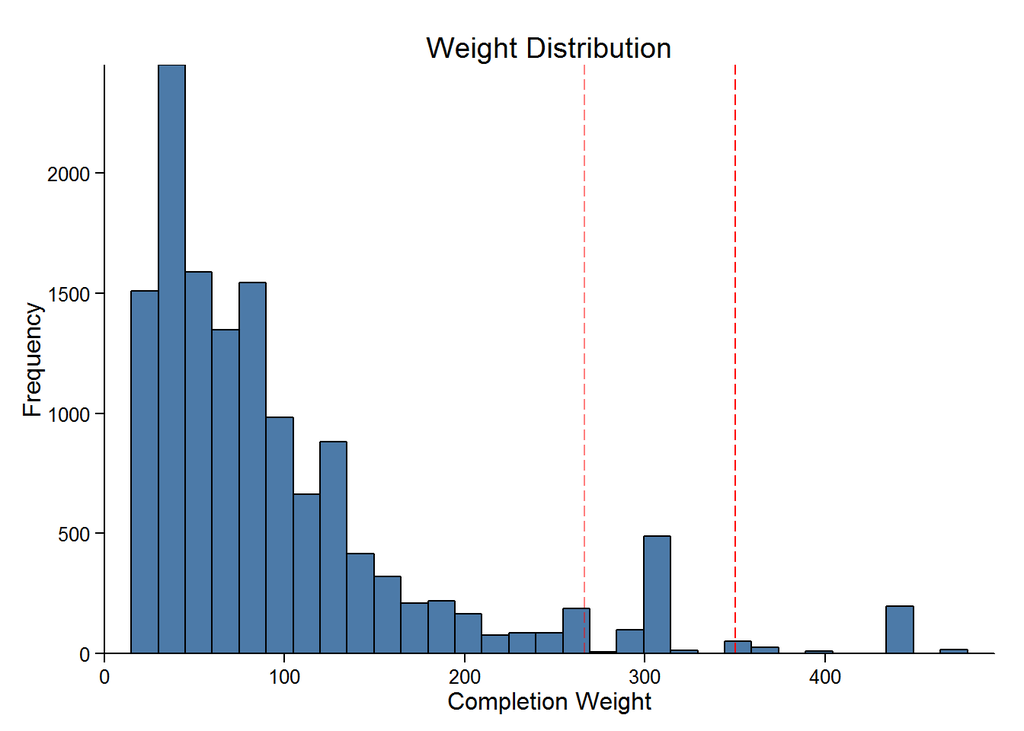

```
##
## Extreme Observations
## ===========================
## STRAT Extreme_Count Max_WGT
## ---------------------------
## 19          8         392
## 76          7         352
## 138        25         368
## 147        200        436
## 153        17         465
## 162         8         353
## ---------------------------
```

#### Function Details:

The dmdc_wts_models function requires two inputs:

| Required Input | Purpose |
| --- | --- |
| Data | Unweighted returns that have been prepared through dmdc_wts_elig |
| model_vars | a list or a text arguement such as `c(Var1,Var2,...VarN)` that contain numeric or nominal predictors for modeling |

| Option | Values |
| --- | --- |
| `verbose` | {`T`/`F`} text tables detailing the internal results of dmdc_wts_models |
| `controls` | Size, Depth and Criterion governing decision trees |
| `plots` | {`T`/`F`} Plots for **ESTATRSP** and **COMPERSP** probabilities |
| `diagnostics` | {`T`/`F`} Extreme weight analysis |

### Step 3 - Adjustments to the population

#### Technical Details:

The final step for completing the analytic weights is to adjust the current weight to the population totals. This can be done in two ways using `RSSCtk`: poststratification or raking. For either methodology we will want population totals; the `RSSCtk` package includes stylized population data to illustrate this example.

#### Poststratification

##### RSSCtk Function and output:

```r
SF1401_pop<-load(demo_pop)
```

```r
names(SF1401_pop)<-toupper(names(SF1401_pop))
dmdc_wts_pstrat(data=SF1401,
                pop=SF1401_pop,
                pop_wgt="COUNT",
                pstrat=c("CSERVICE","CPAYGRP5","CRACECAT"),
                resp = 20,
                min_pstrat=200)
```

```
## Collapsing Convergence Iteration: 1
##  Minimum Respondents Allowed: 20
##  Minimum P-Strat Size: 662
## Poststratification Collapsing Converged...
## Variable P_STRAT was created...
## Variable NP_STRAT was created...
## Variable POSTST_A was created...
## Variable PSTWGT was created...
```

#### Raking

Raking is the process of adjusting the weights so that the marginal totals of the weighted population on specified characteristics will agree with the corresponding totals for the population. The adjustment to control totals is achieved by creating a cross-classification of the categorical control variables (e.g., age categories x gender x race) and then matching the total of the weights in each each cell to the control total. In a simple two variable example, we can imagine starting to rake the weights by taking the ratio of the population total to the weighted sample total for that category and adjusting the weights for each row. We then continue that process for each of the columns. This process continues, alternating between rows and columns, and agreement is usually acheived after a few iterations.

##### RSSCtk Function and output:

```r
dmdc_wts_rake(data=SF1401,
              data_wgts="COMPER_W",
              pop=SF1401_pop,
              pop_wgts="COUNT",
              margins=c("CSERVICE","CPAYGRP5","CREGION1","CSEX"),
              converge=0.001,
              max.iter=10)
```

```
## Variable Rake_A was created...
## Variable RAKEWGT was created...
```

### Final Weighted Data

```r
head(SF1401)
```

```
##   P_STRAT CSERVICE CPAYGRP5 CRACECAT CREGION1 FAMSTAT STRAT PAYGRADE CSEX
## 1       1        1        1        1        1       1     1      E04    1
## 2       1        1        1        1        1       1     1      E04    1
## 3       2        1        1        2        1       4    10      E04    1
## 4       1        1        1        1        1       1     1      E04    1
## 5       1        1        1        1        1       1     1      E04    1
## 6       1        1        1        1        1       1     1      E04    1
##   CEDUC CMARITAL CRACE4 AGE OCCGROUP SAMP_WGT SAMP_DC ELIGFLGW ESTATRSP
## 1     1        1      1  27        1       17       4        1        1
## 2     1        1      1  28        1       17       4        1        1
## 3     1        2      3  23        1       16      11        3        0
## 4     1        1      1  32        3       17       4        1        1
## 5     2        1      1  26        1       17       4        1        1
## 6     1        1      1  23        3       17       4        1        1
##   COMPERSP POSTSTR ELIGS_P COMPER_P ELIGS_A ELIGS_W COMPER_A COMPER_W
## 1        1       1    0.23     0.90     4.3      75      1.1       84
## 2        1       1    0.23     0.90     4.3      75      1.1       84
## 3     <NA>       0    0.15     0.89     0.0       0      0.0        0
## 4        1       1    0.20     0.90     5.0      86      1.1       96
## 5        1       1    0.23     0.90     4.3      75      1.1       84
## 6        1       1    0.17     0.90     5.9     103      1.1      115
##   Count NP_STRAT POSTST_A PSTWGT Rake_A RAKEWGT
## 1     1   114215      2.6    220    2.3     191
## 2     1   114215      2.6    220    2.3     191
## 3     1    93038      2.5      0    2.3       0
## 4     1   114215      2.6    252    2.3     219
## 5     1   114215      2.6    220    2.3     191
## 6     1   114215      2.6    301    2.3     261
```

### Estimates

To calculate final estimates we will use the excellent `survey` package. We will have to correctly specify the design as follows:

```r
library(survey)
des_pop<-svydesign(id=~1,weight=~COUNT,data=SF1401_pop) #population estimates (true totals)
des_pst<-svydesign(id=~1,strata=~STRAT,weight=~PSTWGT,data=SF1401) #poststratified estimates
des_rk<-svydesign(id=~1,strata=~STRAT,weight=~RAKEWGT,data=SF1401) #raked estimates

service<-svytable(~CSERVICE,des_pop) #example of how to calculate an estimate
service #population estimate
```

```
## CSERVICE
##      1      2      3      4
## 486181 322860 184212 307448
```

The table below are the final estimates that would be produced for *SF1401* using `RSSCtk`.

| Variable | Population Value | Poststratification Estimate | Raking Estimate |
| --- | --- | --- | --- |
| Service (CSERVICE) |  | Control: Yes | Control: Yes |
| Army (1) | `486,181` | `486,181` | `486,181` |
| Navy (2) | `322,860` | `322,860` | `322,860` |
| Marine Corps (3) | `184,212` | `184,212` | `184,212` |
| Air Force (4) | `307,448` | `307,448` | `307,448` |
| Paygrade (CPAYGRP5) |  | Control: Yes | Control: Yes |
| E1-E4 (1) | `558,135` | `558,135` | `558,135` |
| E5-E9 (2) | `510,432` | `510,432` | `510,432` |
| W1-W5 (3) | `19,049` | `19,049` | `19,049` |
| O1-O3 (4) | `130,490` | `130,490` | `130,490` |
| O4-O6 (5) | `82,595` | `82,595` | `82,595` |
| Gender (CSEX) |  | Control: No | Control: Yes |
| Male (1) | `1,100,949` | `1,082,681` | `1,100,949` |
| Female (2) | `199,752` | `218,020` | `199,752` |
| Region (CREGION1) |  | Control: No | Control: Yes |
| US & Territories (1) | `1,150,671` | `1,133,029` | `1,150,671` |
| Europe (2) | `66,965` | `77,855` | `66,965` |
| Japan (3) | `83,065` | `89,818` | `83,065` |
| Education (CEDUC) |  | Control: No | Control: No |
| High School (1) | `863,639` | `815,153` | `827,766` |
| Some College (2) | `162,847` | `181,288` | `175,161` |
| College (3) | `168,444` | `187,895` | `188,949` |
| More than College (4) | `105,771` | `116,365` | `108,824` |

The table below is a comparison of the summary of the postratified and raked weights.

| Weight Comparison | Poststratification | Raking |
| --- | --- | --- |
| Sum | `1,300,701` | `1,300,701` |
| Min | `9.4` | `7.5` |
| 1st Qu. | `35` | `31` |
| Median | `51` | `56` |
| Mean | `95` | `93` |
| 3rd Qu. | `150` | `144` |
| Max | `468` | `427` |

## Putting it all together

The block of code below ties the `RSSCtk` process together from start to finish.

```r
#read data

#define eligiblity
dmdc_wgts_elig(data=SF1401,
               disposition="SAMP_DC",
               base_weight="SAMP_WGT",
               strat="STRAT",
               verbose=T)

#select and prepare variables for modeling
model_variables<-c("PAYGRADE","CSERVICE","CRACECAT","CREGION1","FAMSTAT","CSEX","CEDUC","OCCGROUP","AGE")


#model based adjustment for eligiblity and completion
dmdc_wts_models(data=SF1401,
                model_vars=model_variables,
                smooth=T,
                controls=c(minbucket=25,mincriterion=0.95,maxdepth=6,testtype="Teststatistic"),
                verbose=T,
                plots=T,
                diagnostics=T)

#either perform raking or poststratification to adjust to population totals
#poststratification
dmdc_wts_pstrat(data=SF1401,
                pop=SF1401_pop,
                pop_wgt="Count",
                pstrat=c("CSERVICE","CPAYGRP5","CRACECAT"),
                resp = 20,
                min_pstrat=200)

#raking
dmdc_wts_rake(data=SF1401,
              data_wgts="COMPER_W",
              pop=SF1401_pop,
              pop_wgt="Count",
              margins=c("CSERVICE","CPAYGRP5","CREGION1","CSEX"),
              converge=0.001,
              max.iter=10)
```

## References

American Association for Public Opinion Research. (2015). *Standard Definitions: Final Dispositions of Case Codes and Outcome Rates for Surveys.* 8th Edition. AAPOR.

Battaglia (et al). (2004). *Tips and Tricks for Raking Survey Data (aka Sample Balancing).* Cambridge, MA. Abt Associates.

DMDC. (2015). *2014 Status of Forces Survey of Active Duty Members: Statistical Methodology.* (Report No. 2014-041). Alexandria, VA. DMDC.

Valliant (et al). (2003) *Weighting Methods in the July 2002 Status of Forces Survey of Active Duty Personnel*. The Joint Program for Survey Methodology.

## Acknowledgements

`RSSCtk` was developed by Jeff Schneider and Tim Markham